# Table of Contents

## Introduction

In this document there will be statistical analysis of Exercises table. Exercises table has 19 variables (columns) and 483 records. For the analysis below libraries will be used:

- pandas
- numpy
- statistics
- matplotlib.pyplot
- seaborn
- pingouin
- distfit

Below there are information about this dataset (summary info and glimpse of data).

```
<class 'pandas.core.frame.DataFrame'>
RangeIndex: 483 entries, 0 to 482
Data columns (total 19 columns):
 #   Column           Non-Null Count  Dtype
---  ------           --------------  -----
 0   id               483 non-null    int64
 1   user_id          435 non-null    float64
 2   created_at       483 non-null    object
 3   updated_at       483 non-null    object
 4   pro              483 non-null    object
 5   available        483 non-null    object
 6   strength         483 non-null    int64
 7   endurance        483 non-null    int64
 8   technique        483 non-null    int64
 9   flexibility      483 non-null    int64
 10  intensity        483 non-null    int64
 11  code_name        483 non-null    object
 12  name_es          480 non-null    object
 13  name_en          481 non-null    object
 14  description_en   468 non-null    object
 15  description_es   468 non-null    object
 16  auto_generated   483 non-null    object
 17  priority_order   483 non-null    int64
 18  next_program_id  0 non-null      float64
dtypes: float64(2), int64(7), object(10)
memory usage: 71.8+ KB
```

|  | id | user_id | created_at | updated_at | pro | available | strength | endurance | technique | flexibility | intensity | code_name | name_es | name_en | description_en | description_es | auto_generated | priority_order | next_program_id |
| --- | --- | --- | --- | --- | --- | --- | --- | --- | --- | --- | --- | --- | --- | --- | --- | --- | --- | --- | --- |
| 0 | 326 | 773.0 | 2021-09-30 05:34:36.774594 | 2021-09-30 05:34:36.774594 | t | f | 0 | 0 | 0 | 0 | 0 | pro_auto | Innegociable | Pro | Description en | Description es | t | 10 | NaN |
| 1 | 343 | 773.0 | 2021-10-05 10:43:58.6371 | 2021-10-05 10:43:58.6371 | t | f | 0 | 0 | 0 | 0 | 0 | pro_auto | Innegociable | Pro | Description en | Description es | t | 10 | NaN |
| 2 | 22 | 773.0 | 2020-11-23 14:03:11.161414 | 2021-09-29 14:53:34.268573 | f | t | 5 | 4 | 3 | 3 | 4 | PH7-10WO | Lánzate a tu objetivo | Smash your goals | The ultimate program that prepares your body t... | El programa definitivo para que prepares tu mu... | f | 2 | NaN |
| 3 | 92 | NaN | 2021-09-16 15:02:16.599309 | 2021-09-29 14:53:34.694305 | t | f | 0 | 0 | 0 | 0 | 0 | pro_auto | Innegociable | Pro | Description en | Description es | t | 10 | NaN |
| 4 | 10 | 773.0 | 2020-11-23 13:41:46.587265 | 2021-09-29 14:53:34.897432 | f | t | 1 | 3 | 1 | 2 | 2 | PM1 - 5WO | ¡Motívate! | Get motivated! | The ultimate beginner’s program designed to he... | Programa de iniciación diseñado para que incor... | f | 1 | NaN |

Columns

- *user_id*,
- *code_name*,
- *name_es*,
- *description_es*,
- *auto_generated*,
- *priority_order*,
- *next_program_id*

will be dropped, they won't be useful in the analysis.

Variables taken into consideration are

The non-NULL counts, types and glimpse of reduced data are given below.

```
<class 'pandas.core.frame.DataFrame'>
RangeIndex: 483 entries, 0 to 482
Data columns (total 12 columns):
 #   Column          Non-Null Count  Dtype
---  ------          --------------  -----
 0   id              483 non-null    int64
 1   created_at      483 non-null    datetime64[ns]
 2   updated_at      483 non-null    datetime64[ns]
 3   pro             483 non-null    category
 4   available       483 non-null    category
 5   strength        483 non-null    int64
 6   endurance       483 non-null    int64
 7   technique       483 non-null    int64
 8   flexibility     483 non-null    int64
 9   intensity       483 non-null    int64
 10  name_en         481 non-null    object
 11  description_en  468 non-null    object
dtypes: category(2), datetime64[ns](2), int64(6), object(2)
memory usage: 39.0+ KB
```

|  | id | created_at | updated_at | pro | available | strength | endurance | technique | flexibility | intensity | name_en | description_en |
| --- | --- | --- | --- | --- | --- | --- | --- | --- | --- | --- | --- | --- |
| 0 | 326 | 2021-09-30 05:34:36.774594 | 2021-09-30 05:34:36.774594 | True | False | 0 | 0 | 0 | 0 | 0 | Pro | Description en |
| 1 | 343 | 2021-10-05 10:43:58.637100 | 2021-10-05 10:43:58.637100 | True | False | 0 | 0 | 0 | 0 | 0 | Pro | Description en |
| 2 | 22 | 2020-11-23 14:03:11.161414 | 2021-09-29 14:53:34.268573 | False | True | 5 | 4 | 3 | 3 | 4 | Smash your goals | The ultimate program that prepares your body t... |
| 3 | 92 | 2021-09-16 15:02:16.599309 | 2021-09-29 14:53:34.694305 | True | False | 0 | 0 | 0 | 0 | 0 | Pro | Description en |
| 4 | 10 | 2020-11-23 13:41:46.587265 | 2021-09-29 14:53:34.897432 | False | True | 1 | 3 | 1 | 2 | 2 | Get motivated! | The ultimate beginner’s program designed to he... |

There are NULL values only for names and descriptions of the programs.

## Numerical variables

Variables

- *strength*,
- *endurance*,
- *technique*,
- *flexibility* and
- *intensity*

are the only ones that may be considered as numerical variables.

### Summary statistics

Below there is summary statistics about this variable that contains mean, standard deviation, minimum, maximum, quartiles, variance, skewness, kurtosis and NULL count.

|  | count | mean | std | min | 25% | 50% | 75% | max | var | skewness | kurtosis | NULL count |
| --- | --- | --- | --- | --- | --- | --- | --- | --- | --- | --- | --- | --- |
| strength | 483.00 | 0.28 | 1.00 | 0.00 | 0.00 | 0.00 | 0.00 | 5.00 | 1.00 | 3.63 | 12.27 | 0 |
| endurance | 483.00 | 0.27 | 0.93 | 0.00 | 0.00 | 0.00 | 0.00 | 5.00 | 0.86 | 3.43 | 10.46 | 0 |
| technique | 483.00 | 0.19 | 0.68 | 0.00 | 0.00 | 0.00 | 0.00 | 5.00 | 0.47 | 3.93 | 15.42 | 0 |
| flexibility | 483.00 | 0.21 | 0.72 | 0.00 | 0.00 | 0.00 | 0.00 | 4.00 | 0.52 | 3.47 | 11.06 | 0 |
| intensity | 483.00 | 0.29 | 1.03 | 0.00 | 0.00 | 0.00 | 0.00 | 5.00 | 1.07 | 3.60 | 11.96 | 0 |

### Normal distribution evaluation

In this section, the normal distribution evaluation will be done. For this purpose, there will be histogram, qqplot and Shapiro-Wilk test done. Below there is a histogram for numeric variables.

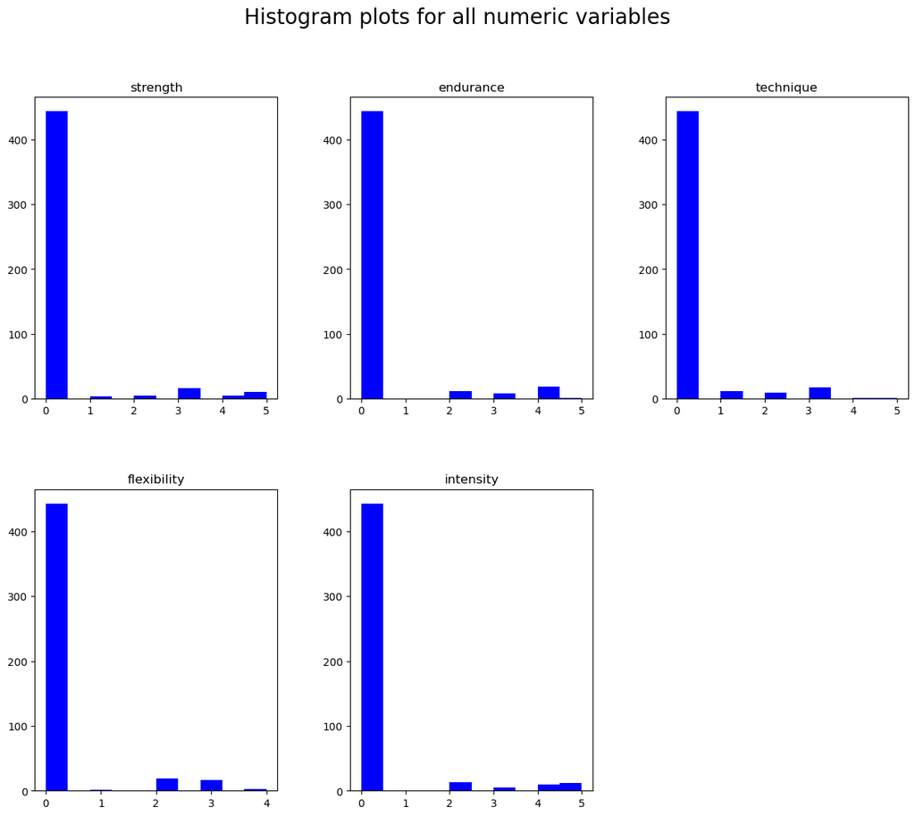

Below there are qqplots for numeric variables.

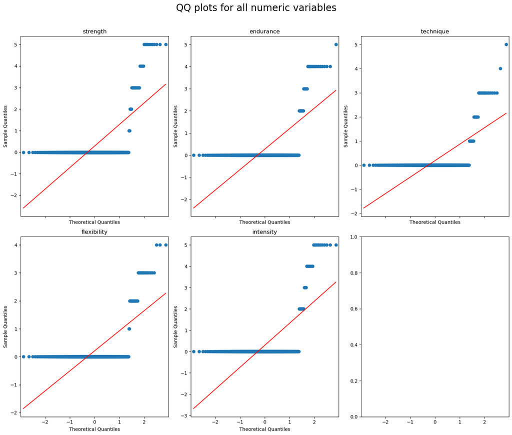

Below there is table with Shapiro-Wilk tests for all of numerical variables.

|  | strength | endurance | technique | flexibility | intensity |
| --- | --- | --- | --- | --- | --- |
| W | 0.30 | 0.31 | 0.30 | 0.31 | 0.31 |
| pval | 0.00 | 0.00 | 0.00 | 0.00 | 0.00 |
| normal | False | False | False | False | False |

There is no normality in the data (from histograms, qqplots and Shapiro-Wilk tets) and kurtosis and skewness also confirms it.

### Data distribution evaluation

In this section, data distribution will be checked (or the closest one). The criterion of determination for best fit is RSS (residual sum of squares). The RSS describes the deviation predicted from actual empirical values of data.

- strength - the most fitting distribution is Wald (RSS = 25.1), then beta (RSS = 28,72), Pearson (RSS = 32.62), half generalized normal (RSS = 32.67) and exponentially normal (RSS = 47.08). The RSS value is very big even with the best fitted distribution.

```
[distfit] >fit..
[distfit] >transform..
[distfit] >[wald       ] [0.02 sec] [RSS: 25.1005] [loc=-0.048 scale=0.160]
[distfit] >[beta       ] [0.13 sec] [RSS: 28.7231] [loc=-0.000 scale=75.717]
[distfit] >[pearson3   ] [0.11 sec] [RSS: 32.6243] [loc=0.181 scale=0.208]
[distfit] >[halfgennorm] [0.12 sec] [RSS: 32.6718] [loc=-0.000 scale=0.003]
[distfit] >[exponnorm  ] [0.05 sec] [RSS: 47.0813] [loc=-0.000 scale=0.000]
[distfit] >Compute confidence interval [parametric]
[distfit] >plot summary..
```

```
(<Figure size 900x400 with 1 Axes>,
 <AxesSubplot:title={'center':'Best fit: wald'}, xlabel='Distribution name', ylabel='RSS (lower is better)'>)
```

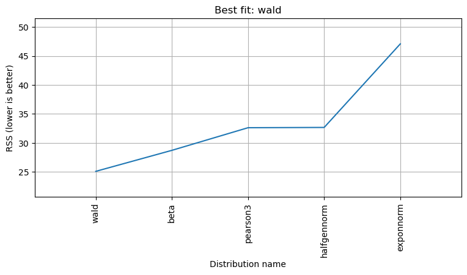

- endurance - the most fitting distribution is Wald (RSS = 23.9), then weibull_min (RSS = 32.22), Pearson (RSS = 32.52), generalized gamma (RSS = 33.08) and erecipinvgauss (RSS = 38.62). The RSS value is very big even with the best fitted distribution.

```
[distfit] >fit..
[distfit] >transform..
[distfit] >[wald         ] [0.01 sec] [RSS: 23.9035] [loc=-0.046 scale=0.152]
[distfit] >[weibull_min  ] [0.07 sec] [RSS: 32.2243] [loc=-0.000 scale=0.021]
[distfit] >[pearson3     ] [0.11 sec] [RSS: 32.5237] [loc=0.135 scale=0.205]
[distfit] >[gengamma     ] [0.16 sec] [RSS: 33.0773] [loc=-0.000 scale=0.014]
[distfit] >[recipinvgauss] [2.41 sec] [RSS: 38.6166] [loc=-0.000 scale=0.231]
[distfit] >Compute confidence interval [parametric]
[distfit] >plot summary..
```

```
(<Figure size 900x400 with 1 Axes>,
 <AxesSubplot:title={'center':'Best fit: wald'}, xlabel='Distribution name', ylabel='RSS (lower is better)'>)
```

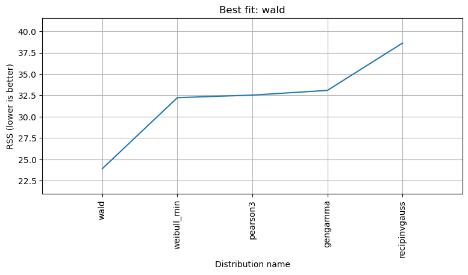

- technique - the most fitting distribution is Wald (RSS = 17.09), then Pearson (RSS = 23.72), exponential weibull (RSS = 27.43), exponentially normal (RSS = 34.48) and generalized exponential (RSS = 34.64). The RSS value is very big even with the best fitted distribution.

```
[distfit] >fit..
[distfit] >transform..
[distfit] >[wald     ] [0.03 sec] [RSS: 17.0852] [loc=-0.032 scale=0.106]
[distfit] >[pearson3 ] [0.15 sec] [RSS: 23.7192] [loc=0.119 scale=0.143]
[distfit] >[exponweib] [0.19 sec] [RSS: 27.4261] [loc=-0.000 scale=0.049]
[distfit] >[exponnorm] [0.06 sec] [RSS: 34.4792] [loc=-0.000 scale=0.000]
[distfit] >[genexpon ] [1.34 sec] [RSS: 34.6391] [loc=-0.000 scale=0.447]
[distfit] >Compute confidence interval [parametric]
[distfit] >plot summary..
```

```
(<Figure size 900x400 with 1 Axes>,
 <AxesSubplot:title={'center':'Best fit: wald'}, xlabel='Distribution name', ylabel='RSS (lower is better)'>)
```

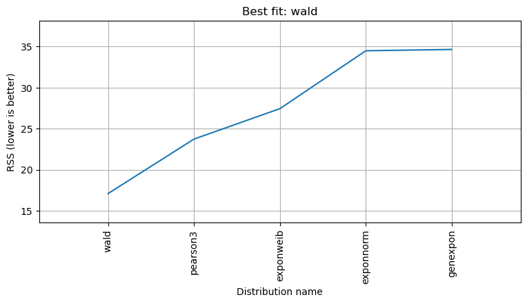

- flexibility - the most fitting distribution is Wald (RSS = 36.26), then recipinvgauss (RSS = 48.7), Pearson (RSS = 50.58), weibull_min (RSS = 51.01), generalized gamma (RSS = 51.7). The RSS value is very big even with the best fitted distribution.

```
[distfit] >fit..
[distfit] >transform..
[distfit] >[wald         ] [0.01 sec] [RSS: 36.2596] [loc=-0.035 scale=0.118]
[distfit] >[recipinvgauss] [2.44 sec] [RSS: 48.6978] [loc=-0.000 scale=0.114]
[distfit] >[pearson3     ] [0.10 sec] [RSS: 50.5818] [loc=0.111 scale=0.166]
[distfit] >[weibull_min  ] [0.07 sec] [RSS: 51.0053] [loc=-0.000 scale=0.016]
[distfit] >[gengamma     ] [0.16 sec] [RSS: 51.6952] [loc=-0.000 scale=0.011]
[distfit] >Compute confidence interval [parametric]
[distfit] >plot summary..
```

```
(<Figure size 900x400 with 1 Axes>,
 <AxesSubplot:title={'center':'Best fit: wald'}, xlabel='Distribution name', ylabel='RSS (lower is better)'>)
```

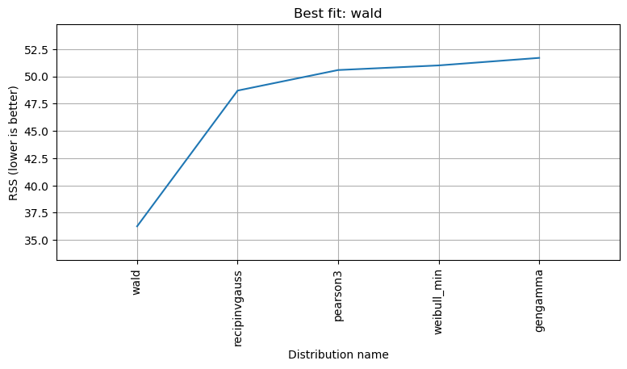

- intensity - the most fitting distribution is Wald (RSS = 25.99), then half generalized normal (RSS = 31.49), Pearson (RSS = 32.87), Gompertz (RSS = 44.95) and generalized gamma (RSS = 47.46). The RSS value is very big even with the best fitted distribution.

```
[distfit] >fit..
[distfit] >transform..
[distfit] >[wald       ] [0.01 sec] [RSS: 25.9933] [loc=-0.050 scale=0.166]
[distfit] >[halfgennorm] [0.16 sec] [RSS: 31.4933] [loc=-0.000 scale=0.003]
[distfit] >[pearson3   ] [0.12 sec] [RSS: 32.8657] [loc=0.183 scale=0.212]
[distfit] >[gompertz   ] [0.13 sec] [RSS: 44.948] [loc=-0.000 scale=1131764266495.251]
[distfit] >[gengamma   ] [0.16 sec] [RSS: 47.4587] [loc=-0.000 scale=0.002]
[distfit] >Compute confidence interval [parametric]
[distfit] >plot summary..
```

```
(<Figure size 900x400 with 1 Axes>,
 <AxesSubplot:title={'center':'Best fit: wald'}, xlabel='Distribution name', ylabel='RSS (lower is better)'>)
```

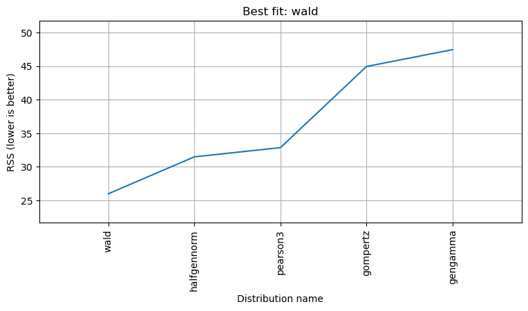

For all of the variables the most fitting distribution is Wald distribution.

It is also possible to consider those variables as categorical, so in the next section they will be considered as that.

## Categorical variables

In this section not only *pro* and *available* are considered as categorical, but also *strength*, *endurance*, *technique*, *flexibility*, *intensity*. Below there are frequency tables and plots of the variables.

| Variable | factors | Frequency | Percent |
| --- | --- | --- | --- |
| Pro |  |  |  |
|  | False | 27.00 | 5.59% |
|  | True | 456.00 | 94.41% |
|  | Total | 483.00 | 100.0% |
| Avaliable |  |  |  |
|  | False | 441.00 | 91.3% |
|  | True | 42.00 | 8.7% |
|  | Total | 483.00 | 100.0% |
| Strength |  |  |  |
|  | 0 | 443.00 | 91.72% |
|  | 1 | 3.00 | 0.62% |
|  | 2 | 5.00 | 1.04% |
|  | 3 | 16.00 | 3.31% |
|  | 4 | 5.00 | 1.04% |
|  | 5 | 11.00 | 2.28% |
|  | Total | 483.00 | 100.0% |
| Endurance |  |  |  |
|  | 0 | 443.00 | 91.72% |
|  | 2 | 12.00 | 2.48% |
|  | 3 | 8.00 | 1.66% |
|  | 4 | 19.00 | 3.93% |
|  | 5 | 1.00 | 0.21% |
|  | Total | 483.00 | 100.0% |
| Technique |  |  |  |
|  | 0 | 443.00 | 91.72% |
|  | 1 | 12.00 | 2.48% |
|  | 2 | 9.00 | 1.86% |
|  | 3 | 17.00 | 3.52% |
|  | 4 | 1.00 | 0.21% |
|  | 5 | 1.00 | 0.21% |
|  | Total | 483.00 | 100.0% |
| Flexibility |  |  |  |
|  | 0 | 443.00 | 91.72% |
|  | 1 | 2.00 | 0.41% |
|  | 2 | 19.00 | 3.93% |
|  | 3 | 16.00 | 3.31% |
|  | 4 | 3.00 | 0.62% |
|  | Total | 483.00 | 100.0% |
| Intensity |  |  |  |
|  | 0 | 443.00 | 91.72% |
|  | 2 | 13.00 | 2.69% |
|  | 3 | 5.00 | 1.04% |
|  | 4 | 10.00 | 2.07% |
|  | 5 | 12.00 | 2.48% |
|  | Total | 483.00 | 100.0% |

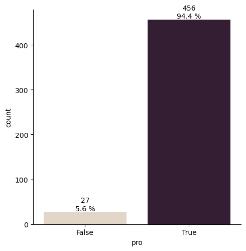

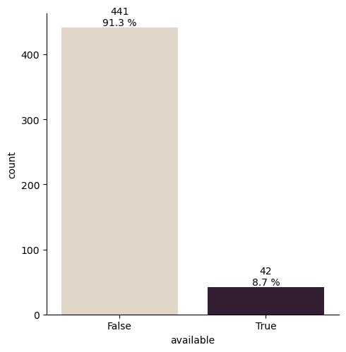

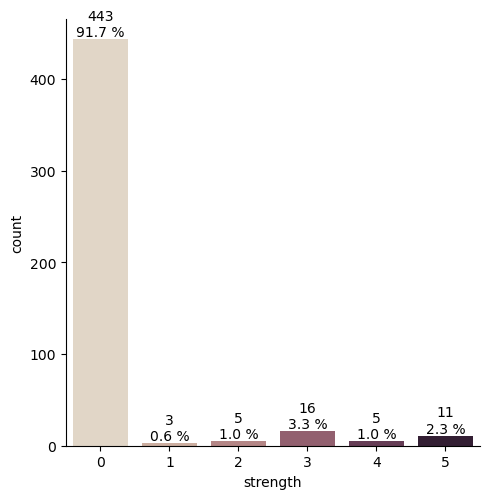

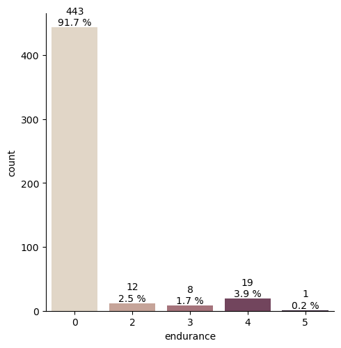

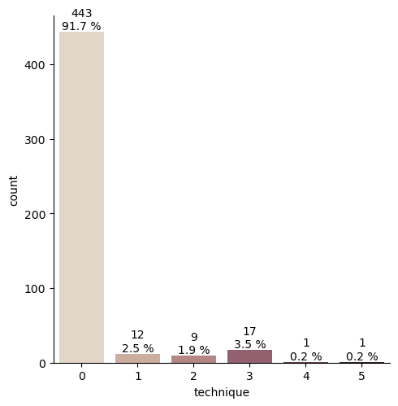

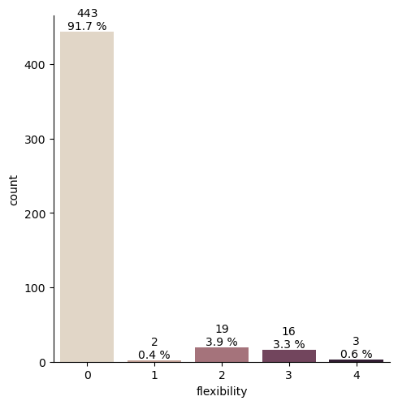

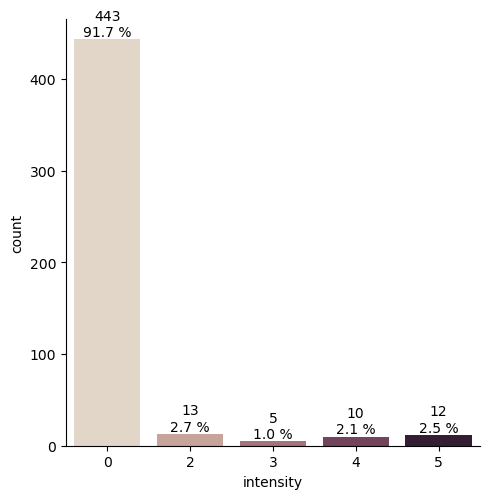